# for_ritvik

Read in the file and eliminate masses < 1.0 Msun where you count becomes incomplete due to extinction

```python
import numpy as np
%matplotlib inline
import smplotlib
import matplotlib.pyplot as plt
import pandas as pd
df=pd.read_csv('rosette10myr.csv')
df=df[df.Mass>=1]
print(len(df))
df[:3]
```

```
160
```

|  | SOURCE_ID | ra | dec | phot_g_mean_mag | phot_bp_mean_mag | phot_rp_mean_mag | ag_gspphot | ebpminrp_gspphot | parallax | ruwe | ... | prob | gabs | onemyr | tenmyr | sixmyr | int_IMF | Mass | logL | logTe | logg |
| --- | --- | --- | --- | --- | --- | --- | --- | --- | --- | --- | --- | --- | --- | --- | --- | --- | --- | --- | --- | --- | --- |
| 0 | 3131394242438349312 | 97.640557 | 5.068388 | 18.097149 | 18.741707 | 17.216913 | 0.8868 | 0.4858 | 0.274072 | 1.015132 | ... | 1.0 | 4.399675 | 0.357252 | 0.021122 | 0.078718 | 2.515931 | 1.270 | 0.121 | 3.7201 | 4.253 |
| 1 | 3131393898840957568 | 97.683943 | 5.039165 | 16.975706 | 18.116040 | 15.885798 | 2.8122 | 1.5776 | 0.617825 | 1.124705 | ... | 1.0 | 3.117835 | 0.471496 | 0.097579 | 0.197778 | 2.536127 | 1.468 | 0.624 | 3.7804 | 4.054 |
| 2 | 3131400663411002752 | 97.707404 | 5.116141 | 17.365377 | 17.935972 | 16.554611 | 1.3236 | 0.7383 | 0.204799 | 0.987266 | ... | 1.0 | 2.598421 | 0.402651 | 0.014599 | 0.138376 | 2.541111 | 1.528 | 0.812 | 3.8049 | 3.982 |

3 rows × 27 columns

Great. We have N=160 sources that we can fit. Let's fit the masses with logarithmic bins below. I'm choosing a random bin size of 0.2.

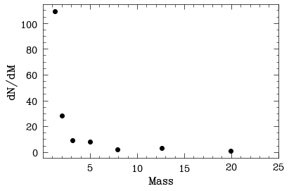

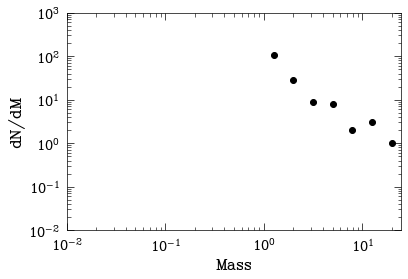

```python
# Convert to logarithm base 10
log_masses = np.log10(df.Mass)
# Define bin width in log-space (0.2 dex)
bin_width = 0.2
# Determine the range for bins
min_log = np.floor(log_masses.min() / bin_width) * bin_width
max_log = np.ceil(log_masses.max() / bin_width) * bin_width
# Create the bin edges. Adding one extra step so the upper edge is included.
bins = np.arange(min_log, max_log + bin_width, bin_width)
# Bin the data using np.histogram (counts in each bin)
counts, edges = np.histogram(log_masses, bins=bins)
# Calculate midpoints of the bins
midpoints = (edges[:-1] + edges[1:]) / 2

plt.rcParams.update({'font.size': 16})
plt.scatter(10**midpoints, counts,color='black',label='Counts from our FOV')
plt.xlabel('Mass',fontsize=18)
plt.ylabel('dN/dM',fontsize=18)
plt.xlim(0.01,25)
plt.show()
plt.scatter(10**midpoints, counts,color='black',label='Counts from our FOV')
plt.xlabel('Mass',fontsize=18)
plt.ylabel('dN/dM',fontsize=18)
plt.loglog()
plt.ylim(1.0e-2,1.0e3)
plt.xlim(0.01,25)
plt.show()
```

Note that the same data look different depending on whether or not you're plotting in logarithmic space. The second plot is logarithmically-spaced dN/dM versus dM plot, while the first shows these same values in linear space.

Next we will do the same logarithmic binning, but we will choose a bin width such that the powerlaw fit to our observed sources (all masses>1.0 Msun) corresponds to the -2.12 exponent found by Muzic+2019.

```
A = 135 ± 5.01
n = 2.17 ± 0.106
```

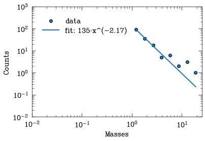

```python
# Convert to logarithm base 10
log_masses = np.log10(df.Mass)
# Define bin width in log-space (0.2 dex)
bin_width = 0.17
# Determine the range for bins
min_log = np.floor(log_masses.min() / bin_width) * bin_width
max_log = np.ceil(log_masses.max() / bin_width) * bin_width
# Create the bin edges. Adding one extra step so the upper edge is included.
bins = np.arange(min_log, max_log + bin_width, bin_width)
# Bin the data using np.histogram (counts in each bin)
counts, edges = np.histogram(log_masses, bins=bins)
# Calculate midpoints of the bins
midpoints = (edges[:-1] + edges[1:]) / 2

def powerlaw(x, A, n):
    return A * x**(-n)
A0 = np.max(counts)            # amplitude above the floor
n0 = 1.0                       # typical power‐law slope
p0 = [A0, n0]

# optional: enforce positivity on all parameters
bounds = (0, np.inf)
popt, pcov = curve_fit(powerlaw, 10**midpoints, counts, p0=p0, bounds=bounds)
A_fit, n_fit = popt
perr = np.sqrt(np.diag(pcov))

print(f"A = {A_fit:.3g} ± {perr[0]:.3g}")
print(f"n = {n_fit:.3g} ± {perr[1]:.3g}")
#print(f"C = {C_fit:.3g} ± {perr[2]:.3g}")
xs = np.linspace(np.min(10**midpoints), np.max(10**midpoints), 200)
ys = powerlaw_floor(xs, *popt)

plt.figure()
plt.scatter(10**midpoints, counts, label="data")
plt.plot(xs, ys, label=f"fit: {round(A_fit)}·x^(-{n_fit:.2f})", lw=2)
plt.xlim(0.01,25)
plt.ylim(1.0e-2,1.0e3)
plt.xlabel("Masses")
plt.ylabel("Counts")
plt.legend()
plt.loglog()
plt.show()
```

Great. We also calculated the scaling factor, A, which is the value we need to get our FOV count when we integrate the IMF. This is bin-width dependent, hence the necessary step of a priori choosing a bin width that agrees with the Muzic+2019 analysis.

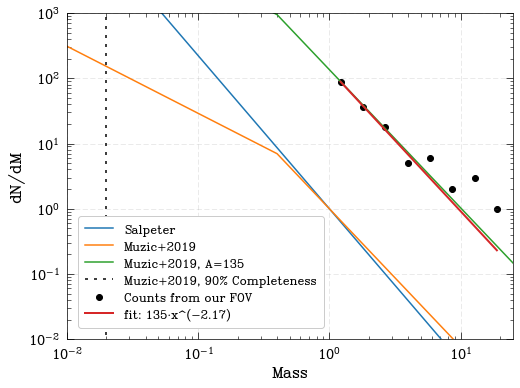

```python
def salpeter(m, slope=-2.35) :
    """ Salpeter IMF, single power law
    """
    return m**slope
def rosette(m) :
    """ 2-segment power law
    """
    # for efficiency, initialize output array and fill 3 sections separately
    imf = np.zeros(np.shape(m))
    j=np.where((m>0.4))[0]
    imf[j] = m[j]**-2.12
    j=np.where((m>0.001)&(m<=0.4))[0]
    imf[j] = 0.4**(-2.12+1.03)*m[j]**-1.03
    return imf

mass=np.arange(0.01,100,0.01)
plt.figure(figsize=(8, 6))
plt.plot(mass,salpeter(mass),label='Salpeter')
plt.plot(mass,rosette(mass),label='Muzic+2019')
plt.plot(mass,rosette(mass)*A_fit,label=f"Muzic+2019, A={round(A_fit)}")
plt.vlines(0.02,0,1.0e4,ls='dotted',label='Muzic+2019, 90% Completeness')
#ritvik, change the array below to reflect the masses you found in your investigation
masses=[0.1,1,1.1,10,2.3,4.,0.1,0.3,0.5,0.6,7.1]

plt.scatter(10**midpoints, counts,color='black',label='Counts from our FOV')
plt.plot(xs, ys, label=f"fit: {round(A_fit)}·x^(-{n_fit:.2f})", lw=2)
plt.ylim(1.0e-2,1.0e3)
plt.xlim(0.01,25)
plt.legend(fontsize=14,frameon=True,loc='lower left')
plt.loglog()
plt.xlabel('Mass',fontsize=18)
plt.ylabel('dN/dM',fontsize=18)
plt.grid(alpha=0.2)
```

Great, using this framework, we would take 135 as our scaling factor, multiplying your integrated IMF values by this factor to determine the total number of sources monitored.